# Algorithmic Trading Model for Simple Trend-Following Strategy Using Python Take 3

### January 5, 2021

NOTE: This script is for learning purposes only and does not constitute a recommendation for buying or selling any stock mentioned in this script.

SUMMARY: This project aims to construct and test an algorithmic trading model and document the end-to-end steps using a template.

INTRODUCTION: This algorithmic trading model examines a simple trend-following strategy for a stock. The model buys a stock when the price reaches the highest price for the last X number of days. The model will exit the long position when the stock price crosses below the mean of the same window size. Conversely, the model shorts a stock when the price reaches below the lowest price for the last X number of days. The model will exit the short position when the stock price crosses above the mean of the same window size.

From iteration Take1, we set up the models using one fixed window size for long trades only. The window size varied from 10 to 50 trading days at a 5-day increment.

From iteration Take2, we set up the models using one fixed window size for long trades only. The window size will vary from 10 to 50 trading days at a 5-day increment. The models also considered a volume indicator with its window size to confirm the buy/sell signal.

In this Take3 iteration, we will set up the models using one fixed window size for long and short trades. The window size will vary from 10 to 50 trading days at a 5-day increment.

ANALYSIS: From iteration Take1, we analyzed the stock prices for Apple Inc. (AAPL) between January 1, 2019, and December 24, 2020. The trading model produced a profit of 81.49 dollars per share. The buy-and-hold approach yielded a gain of 92.60 dollars per share.

From iteration Take2, we analyzed the stock prices for Apple Inc. (AAPL) between January 1, 2019, and December 24, 2020. The trading model produced a profit of 82.47 dollars per share. The buy-and-hold approach yielded a gain of 92.60 dollars per share.

In this Take3 iteration, we analyzed the stock prices for Apple Inc. (AAPL) between January 1, 2019, and December 24, 2020. The trading model produced a profit of 79.95 dollars per share. The buy-and-hold approach yielded a gain of 92.60 dollars per share.

CONCLUSION: For the stock of AAPL during the modeling time frame, the trading strategy did not produce a better return than the buy-and-hold approach. We should consider modeling this stock further by experimenting with more variations of the strategy.

Dataset ML Model: Time series analysis with numerical attributes

Dataset Used: Quandl

An algorithmic trading modeling project generally can be broken down into about five major tasks:

1. Prepare Environment
2. Acquire and Pre-Process Data
3. Implement and Train Models
4. Back-test Models
5. Evaluate Strategy Performance

## Task 1 - Prepare Environment

```python
# # Install the necessary packages for Colab
# !pip install python-dotenv PyMySQL
```

```python
# # Retrieve the GPU information from Colab
# gpu_info = !nvidia-smi
# gpu_info = '\n'.join(gpu_info)
# if gpu_info.find('failed') >= 0:
#     print('Select the Runtime → "Change runtime type" menu to enable a GPU accelerator, ')
#     print('and then re-execute this cell.')
# else:
#     print(gpu_info)
```

```python
# # Retrieve the memory configuration from Colab
# from psutil import virtual_memory
# ram_gb = virtual_memory().total / 1e9
# print('Your runtime has {:.1f} gigabytes of available RAM\n'.format(ram_gb))
#
# if ram_gb < 20:
#     print('To enable a high-RAM runtime, select the Runtime → "Change runtime type"')
#     print('menu, and then select High-RAM in the Runtime shape dropdown. Then, ')
#     print('re-execute this cell.')
# else:
#     print('You are using a high-RAM runtime!')
```

```python
# # Retrieve the CPU information
# ncpu = !nproc
# print("The number of available CPUs is:", ncpu[0])
```

### 1.a) Load libraries and modules

```python
import pandas as pd
import matplotlib.pyplot as plt
import os
import sys
from datetime import date, datetime, timedelta
import requests
import json
from dotenv import load_dotenv
# import pandas_datareader.data as pdr

# Begin the timer for the script processing
startTimeScript = datetime.now()
```

### 1.b) Set up the controlling parameters and functions¶

```python
# Specify the key modeling parameters below
STOCK_SYMBOL = 'AAPL'
INITIAL_CAPITAL = 0

# Specify the moving average parameters for the trading strategy
WINDOW_MIN = 10
WINDOW_MAX = 50
WINDOW_INCREMENT = 5

# The number of extra days of data we need for calculating moving averages (usually equals to the largest value of slow MA)
EXTRA_DAYS = WINDOW_MAX

MODEL_START_DATE = date(2019, 1, 1)
print("Starting date for the model:", MODEL_START_DATE)

MODEL_END_DATE = datetime.now().date()
MODEL_END_DATE = date(2020, 12, 24)
print("Ending date for the model:", MODEL_END_DATE)

# data_start_date = MODEL_START_DATE
data_start_date = MODEL_START_DATE - timedelta(days=int(EXTRA_DAYS * 1.5)) # Need more pricing data to calculate moving averages
print("First date of data we need for modeling:", data_start_date)

data_end_date = MODEL_END_DATE
print("Last date of data we need for modeling:", data_end_date)
```

```
Starting date for the model: 2019-01-01
Ending date for the model: 2020-12-24
First date of data we need for modeling: 2018-10-18
Last date of data we need for modeling: 2020-12-24
```

```python
# Specify the script running parameters below

# Set Pandas options
pd.set_option("display.max_rows", None)
pd.set_option("display.max_columns", None)
pd.set_option("display.width", 255)

# Configure the plotting style
plt.style.use('seaborn')

# Set up the verbose flag to print detailed messages for debugging (setting True will activate!)
verbose_signals = False
verbose_models = True
verbose_graphs = True
verbose_trade_actions = True
verbose_portfolios = False
verbose_transactions = False
verbose_positions = True
```

```python
# Set up the parent directory location for loading the dotenv files

# Mount Google Drive locally for storing files
# from google.colab import drive
# drive.mount('/content/gdrive')
# gdrivePrefix = '/content/gdrive/My Drive/Colab_Downloads/'
# env_path = '/content/gdrive/My Drive/Colab Notebooks/'
# dotenv_path = env_path + "python_script.env"
# load_dotenv(dotenv_path=dotenv_path)

# Set up access to the dotenv file on local PC
env_path = "/Users/david/PycharmProjects/"
dotenv_path = env_path + "python_script.env"
load_dotenv(dotenv_path=dotenv_path)
```

```
True
```

## Task 2 - Acquire and Pre-Process Data

```python
# Set up the data service provider and data acquisition parameters
data_service = 'Quandl'

# Check and see whether the API key is available
api_key = os.environ.get('QUANDL_API')
if api_key is None: sys.exit("API key for Quandl not available. Script Processing Aborted!!!")

start_date_string = data_start_date.strftime('%Y-%m-%d')
end_date_string = data_end_date.strftime('%Y-%m-%d')
api_url = "https://www.quandl.com/api/v3/datatables/SHARADAR/SEP.json?date.gte=%s&date.lte=%s&ticker=%s&api_key=%s" % (start_date_string, end_date_string, STOCK_SYMBOL, api_key)
response = requests.get(api_url)
resp_dict = json.loads(response.text)
stock_rawdata = pd.DataFrame(resp_dict['datatable']['data'])
print(len(stock_rawdata), 'data points retrieved from the API call.')
```

```
551 data points retrieved from the API call.
```

```python
stock_rawdata.columns = ['ticker', 'date', 'open', 'high', 'low', 'close', 'volume', 'dividend', 'closeunadj', 'lastupdated']
# stock_rawdata.set_index('date', inplace=True)
stock_rawdata.index = pd.to_datetime(stock_rawdata.date)
stock_pricing = stock_rawdata.sort_index(ascending=True)
print(stock_pricing.head())
print()
print(stock_pricing.tail())
```

```
           ticker        date    open    high     low   close       volume  dividend  closeunadj lastupdated
date
2018-10-18   AAPL  2018-10-18  54.465  54.935  53.250  54.005  130325260.0       0.0      216.02  2020-08-31
2018-10-19   AAPL  2018-10-19  54.515  55.315  54.358  54.828  132314904.0       0.0      219.31  2020-08-31
2018-10-22   AAPL  2018-10-22  54.947  55.840  54.735  55.163  115168328.0       0.0      220.65  2020-08-31
2018-10-23   AAPL  2018-10-23  53.958  55.813  53.675  55.682  155071384.0       0.0      222.73  2020-08-31
2018-10-24   AAPL  2018-10-24  55.650  56.057  53.635  53.773  163700652.0       0.0      215.09  2020-08-31

           ticker        date    open     high      low    close       volume  dividend  closeunadj lastupdated
date
2020-12-18   AAPL  2020-12-18  128.96  129.100  126.120  126.655  192541496.0       0.0     126.655  2020-12-18
2020-12-21   AAPL  2020-12-21  125.02  128.310  123.449  128.230  121251553.0       0.0     128.230  2020-12-21
2020-12-22   AAPL  2020-12-22  131.61  134.405  129.650  131.880  169351825.0       0.0     131.880  2020-12-22
2020-12-23   AAPL  2020-12-23  132.16  132.430  130.780  130.960   87689496.0       0.0     130.960  2020-12-23
2020-12-24   AAPL  2020-12-24  131.32  133.460  131.100  131.970   54902010.0       0.0     131.970  2020-12-24
```

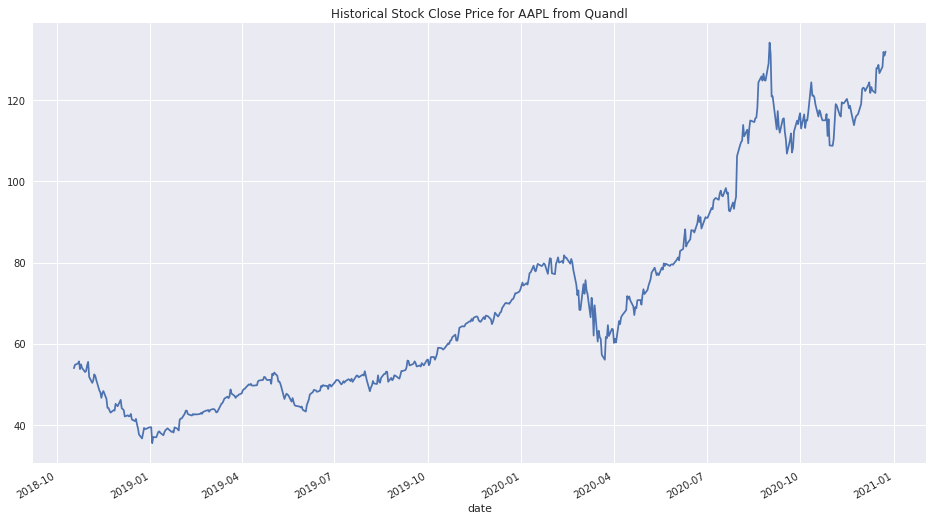

```python
# Set up the standard column name for modeling
# Column names may be data-provider specific!
MODEL_TEMPLATE = stock_pricing.loc[:, ['open','close','volume']]
MODEL_TEMPLATE.rename(columns={'open': 'open_price', 'close': 'close_price', 'volume': 'trading_volume'}, inplace=True)
plot_title = 'Historical Stock Close Price for ' + STOCK_SYMBOL + ' from ' + data_service
MODEL_TEMPLATE['close_price'].plot(figsize=(16,9), title=plot_title)
plt.show()
```

## Task 3 - Implement and Train Models

```python
# Define the function that will generate the indicators and trading signals
def populate_signals(window=WINDOW_MIN):

    trade_model = MODEL_TEMPLATE.copy()
    trade_model['window_high'] = trade_model['close_price'].shift(1).rolling(window=window).max()
    trade_model['window_low'] = trade_model['close_price'].shift(1).rolling(window=window).min()
    trade_model['window_avg'] = trade_model['close_price'].shift(1).rolling(window=window).mean()
    trade_model['buy_on_open'] = False
    trade_model['sell_on_open'] = False
    trade_model['short_on_open'] = False
    trade_model['cover_on_open'] = False
    trade_model['position_long'] = False
    trade_model['position_short'] = False
    trade_model['close_above_avg'] = False
    trade_model['close_below_avg'] = False

    # Truncate the model to the required starting and ending dates
    trade_model = trade_model[MODEL_START_DATE:MODEL_END_DATE]
    last_index = len(trade_model) - 1

    for k in range(len(trade_model)):
        breakout_high = trade_model.at[trade_model.index[k],'close_price'] - trade_model.at[trade_model.index[k],'window_high']
        crossover = trade_model.at[trade_model.index[k],'close_price'] - trade_model.at[trade_model.index[k],'window_avg']
        breakout_low = trade_model.at[trade_model.index[k],'close_price'] - trade_model.at[trade_model.index[k],'window_low']
        if k == 0:
            currently_long = False
            currently_short = False
        else:
            currently_long = trade_model.at[trade_model.index[k-1],'position_long']
            currently_short = trade_model.at[trade_model.index[k-1],'position_short']

        # Check to see whether we need to execute any trade action on open
        if trade_model.at[trade_model.index[k],'buy_on_open']:
            trade_model.at[trade_model.index[k],'position_long'] = True
        elif trade_model.at[trade_model.index[k],'short_on_open']:
            trade_model.at[trade_model.index[k],'position_short'] = True
        elif trade_model.at[trade_model.index[k],'sell_on_open']:
            trade_model.at[trade_model.index[k],'position_long'] = False
        elif trade_model.at[trade_model.index[k],'cover_on_open']:
            trade_model.at[trade_model.index[k],'position_short'] = False
        else:
            # If no trade on open, check to see whether we have a breakout either way
            if (breakout_high >= 0) and (not currently_long) and (not currently_short) and (k < last_index-1):
                trade_model.at[trade_model.index[k+1],'buy_on_open'] = True
            elif (breakout_low < 0) and (not currently_long) and (not currently_short) and (k < last_index-1):
                trade_model.at[trade_model.index[k+1],'short_on_open'] = True
            else:
                # If no breakout, check to see whether we need to exit an existing position
                if crossover >= 0:
                    trade_model.at[trade_model.index[k],'close_above_avg'] = True
                    if currently_short and (k > 0) and (k < last_index-1) and trade_model.at[trade_model.index[k-1],'close_below_avg']:
                        trade_model.at[trade_model.index[k+1],'cover_on_open'] = True
                else:
                    trade_model.at[trade_model.index[k],'close_below_avg'] = True
                    if currently_long and (k > 0) and (k < last_index-1) and trade_model.at[trade_model.index[k-1],'close_above_avg']:
                        trade_model.at[trade_model.index[k+1],'sell_on_open'] = True

            # If no action on a given day, carry over the position status
            if (k > 0) and (not trade_model.at[trade_model.index[k],'buy_on_open']) and (not trade_model.at[trade_model.index[k],'sell_on_open']) and (not trade_model.at[trade_model.index[k],'short_on_open']) and (not trade_model.at[trade_model.index[k],'cover_on_open']):
                trade_model.at[trade_model.index[k],'position_long'] = trade_model.at[trade_model.index[k-1],'position_long']
                trade_model.at[trade_model.index[k],'position_short'] = trade_model.at[trade_model.index[k-1],'position_short']

        # # Exiting the position on the last day of modeling period
        # if k == last_index-1:
        #     if trade_model.at[trade_model.index[k],'position_long']:
        #         trade_model.at[trade_model.index[k+1],'sell_on_open'] = True
        #         trade_model.at[trade_model.index[k+1],'position_long'] = False
        #     elif trade_model.at[trade_model.index[k],'position_short']:
        #         trade_model.at[trade_model.index[k+1],'cover_on_open'] = True
        #         trade_model.at[trade_model.index[k+1],'position_short'] = False

    if verbose_signals: print(trade_model, '\n')
    return trade_model
```

```python
# Build the collection of trading models by iterating through the parameters
trading_model_collection = {}
serial_no = 0
for window_size in range(WINDOW_MIN, WINDOW_MAX+1, WINDOW_INCREMENT):
    serial_no += 1
    model_tag = 'Model_' + str(serial_no).zfill(3) + '_WINDOW_' + str(window_size).zfill(2)
    if verbose_signals: print('Processing model:', model_tag)
    trading_model = populate_signals(window_size)
    trading_model_collection[model_tag] = trading_model.copy()
print(len(trading_model_collection), 'trading models generated!')
```

```
9 trading models generated!
```

```python
# List the entry/exit points for each model
def list_model_entry_exit(trade_model):
    print(trade_model[trade_model['buy_on_open'] | trade_model['sell_on_open'] | trade_model['short_on_open'] | trade_model['cover_on_open']])
```

```python
if verbose_models:
    for model_name in trading_model_collection:
        print('List the signal changes and entry/exit points for model:', model_name)
        list_model_entry_exit(trading_model_collection[model_name])
        print()
```

```
List the signal changes and entry/exit points for model: Model_001_WINDOW_10
            open_price  close_price  trading_volume  window_high  window_low  window_avg  buy_on_open  sell_on_open  short_on_open  cover_on_open  position_long  position_short  close_above_avg  close_below_avg
date
2019-01-04      36.133       37.065     234428280.0       40.222      35.547     38.5669        False         False           True          False          False            True            False            False
2019-01-10      38.125       38.450     143122680.0       39.480      35.547     38.1913        False         False          False           True          False           False            False            False
2019-01-18      39.375       39.205     135004092.0       38.965      36.983     38.0053         True         False          False          False           True           False            False            False
2019-01-25      38.870       39.440     134191572.0       39.205      37.500     38.4174        False          True          False          False          False           False            False            False
2019-01-31      41.528       41.610     162958596.0       41.313      38.175     39.0383         True         False          False          False           True           False            False            False
2019-02-19      42.428       42.733      75891304.0       43.560      42.358     42.8185        False          True          False          False          False           False            False            False
2019-02-25      43.540       43.557      87493432.0       43.242      42.358     42.7280         True         False          False          False           True           False            False            False
2019-03-08      42.580       43.227      95997432.0       43.962      43.125     43.5730        False          True          False          False          False           False            False            False
2019-03-12      45.000       45.227     129870336.0       44.725      43.125     43.6883         True         False          False          False           True           False            False            False
2019-03-27      47.188       47.117     119393708.0       48.773      45.428     46.8986        False          True          False          False          False           False            False            False
2019-04-04      48.697       48.922      76457100.0       48.837      46.697     47.7354         True         False          False          False           True           False            False            False
2019-05-01      52.470       52.630     259309312.0       51.870      49.813     51.0068        False          True          False          False          False           False            False            False
2019-05-06      51.072       52.120     129772452.0       52.938      50.167     51.6364         True         False          False          False           True           False            False            False
2019-06-26      49.443       49.950     104270048.0       49.865      48.185     49.0919        False          True          False          False          False           False            False            False
2019-07-02      50.352       50.682      67740868.0       50.388      48.892     49.6930         True         False          False          False           True           False            False            False
2019-07-09      49.800       50.310      82312060.0       51.102      48.892     50.1136        False          True          False          False          False           False            False            False
2019-07-16      51.148       51.125      67467264.0       51.303      50.005     50.6917         True         False          False          False           True           False            False            False
2019-07-22      50.913       51.805      89111728.0       51.415      50.005     50.7713        False          True          False          False          False           False            False            False
2019-07-24      51.917       52.167      59966268.0       52.210      50.438     51.1413         True         False          False          False           True           False            False            False
2019-08-05      49.498       48.335     209571876.0       53.260      51.005     52.0860        False          True          False          False          False           False            False            False
2019-08-20      52.720       52.590     107678116.0       52.587      49.250     50.7813         True         False          False          False           True           False            False            False
2019-08-26      51.465       51.623     104264520.0       53.160      50.120     51.7222        False          True          False          False          False           False            False            False
2019-09-06      53.513       53.315      76928340.0       53.320      50.660     51.9300         True         False          False          False           True           False            False            False
```

[output cut: 228 more lines]

```python
def draw_model_graph(trade_model, mdl_name=STOCK_SYMBOL):
    graph_data = trade_model.copy()
    title_string = 'Simple Trend-Following Trading Model for ' + mdl_name
    fig = plt.figure(figsize=(16,9))
    ylabel = STOCK_SYMBOL + ' price in $'
    ax1 = fig.add_subplot(111, ylabel=ylabel, title=title_string)
    graph_data['close_price'].plot(ax=ax1, color='g')
    ax1.plot(graph_data.loc[graph_data['buy_on_open']].index, graph_data.close_price[graph_data['buy_on_open']], '^', markersize=7, color='b',label='Buy on Open')
    ax1.plot(graph_data.loc[graph_data['sell_on_open']].index, graph_data.close_price[graph_data['sell_on_open']], 'v', markersize=7, color='b',label='Sell on Open')
    ax1.plot(graph_data.loc[graph_data['short_on_open']].index, graph_data.close_price[graph_data['short_on_open']], '^', markersize=7, color='r',label='Short on Open')
    ax1.plot(graph_data.loc[graph_data['cover_on_open']].index, graph_data.close_price[graph_data['cover_on_open']], 'v', markersize=7, color='r',label='Cover on Open')
    plt.legend(loc='upper left')
    plt.show()
```

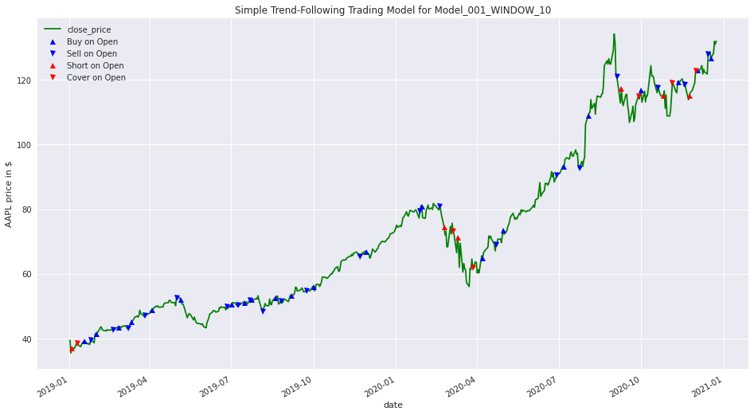

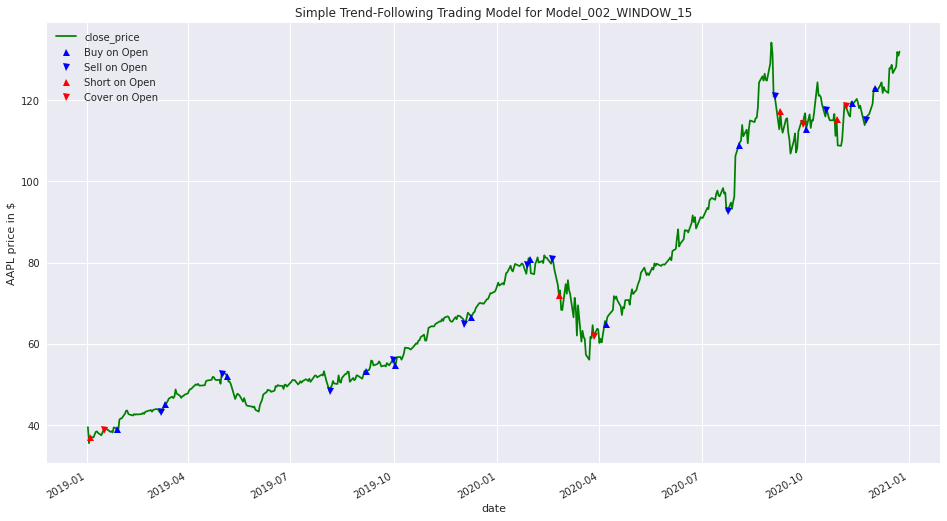

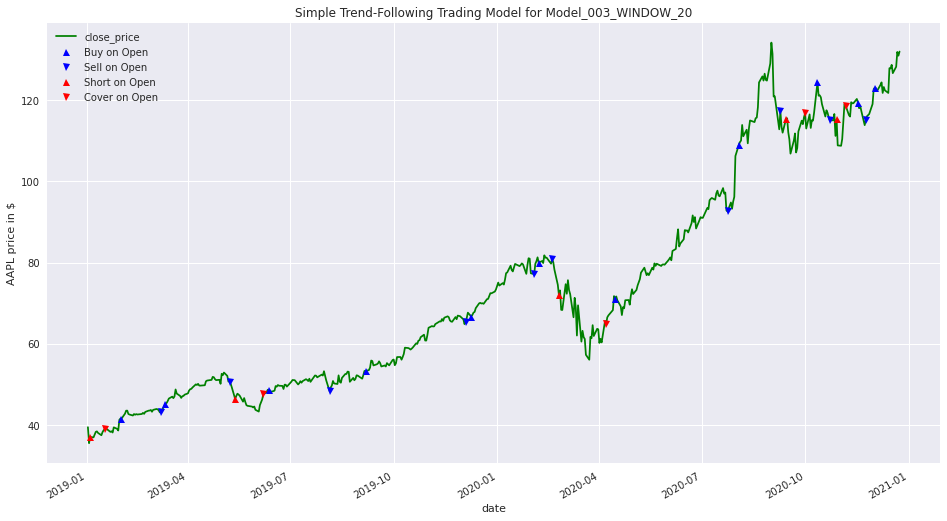

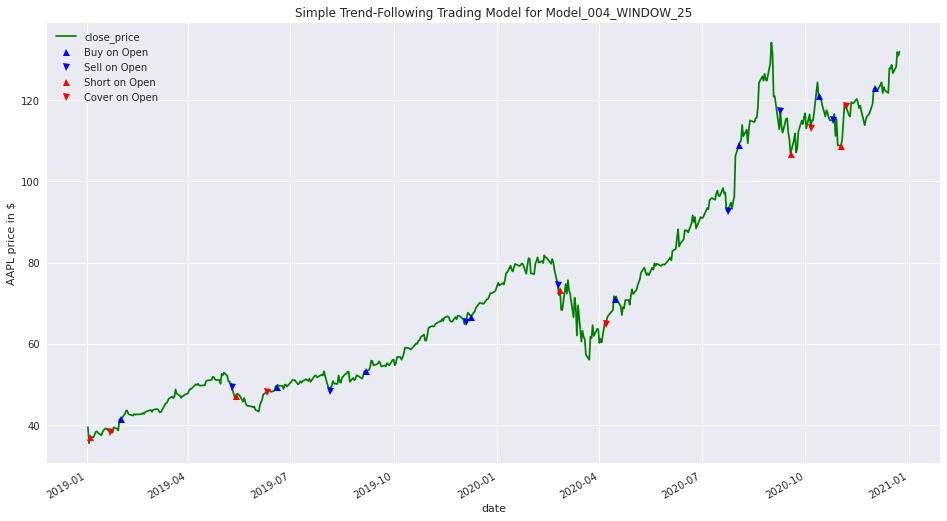

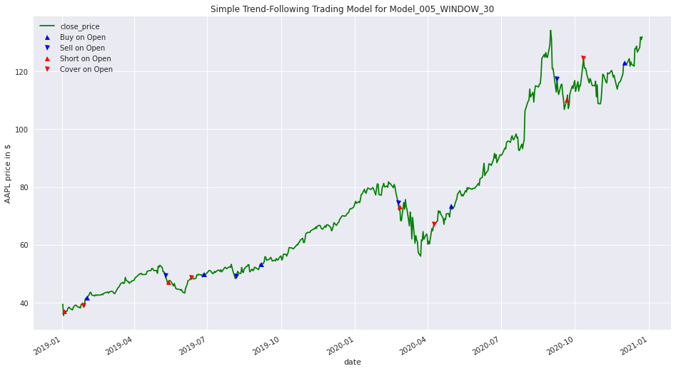

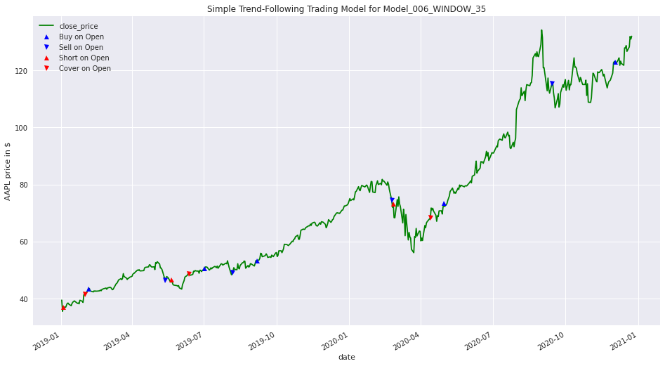

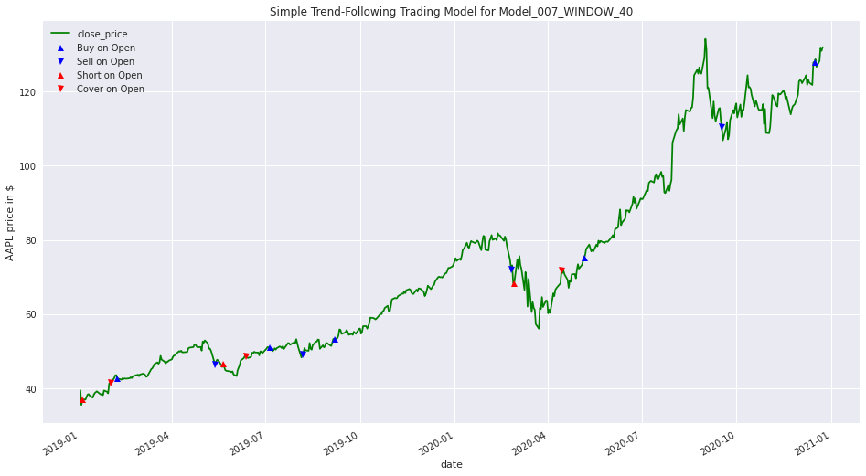

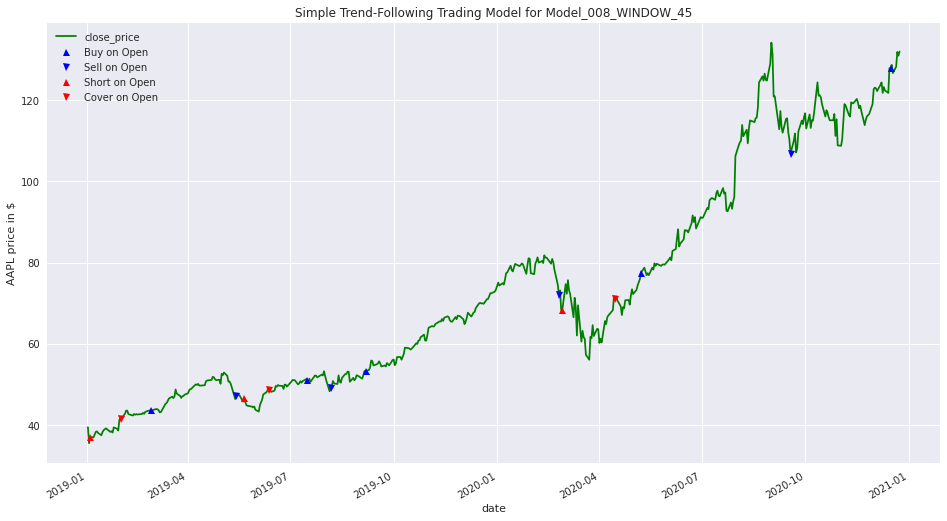

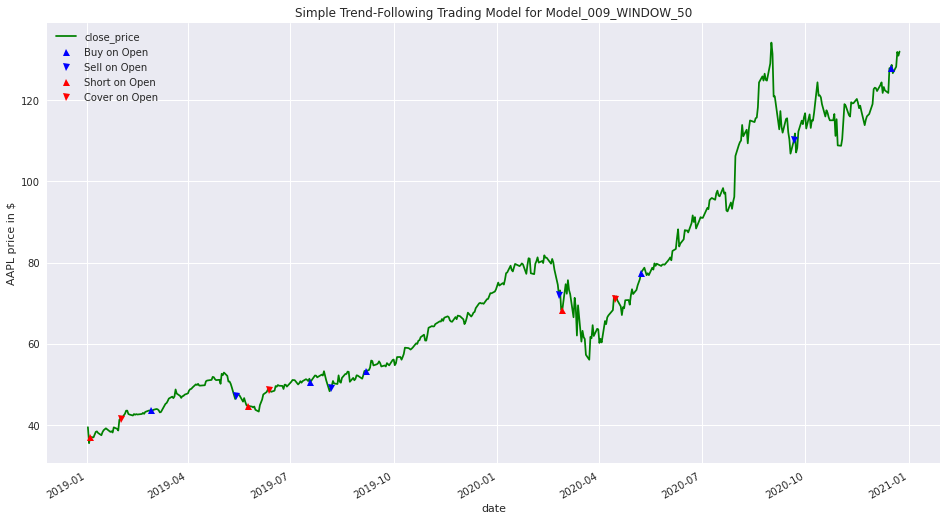

```python
if verbose_graphs:
    for model_name in trading_model_collection:
        draw_model_graph(trading_model_collection[model_name], model_name)
```

## Task 4 - Back-test Models

```python
def generate_trading_portfolios(trade_model):
    # Construct a portfolio to track the transactions and returns
    portfolio = pd.DataFrame(index=trade_model.index, columns=['trade_action', 'price_executed', 'qty_transacted', 'cost_basis', 'gain_loss', 'qty_on_hand', 'cash_on_hand', 'position_value', 'total_position', 'accum_return'])
    portfolio['trade_action'] = False
    portfolio.at[portfolio.index[0],'price_executed'] = 0.00
    portfolio.at[portfolio.index[0],'qty_transacted'] = 0
    portfolio.at[portfolio.index[0],'cost_basis'] = 0.00
    portfolio.at[portfolio.index[0],'gain_loss'] = 0.00
    portfolio.at[portfolio.index[0],'qty_on_hand'] = 0
    portfolio.at[portfolio.index[0],'cash_on_hand'] = INITIAL_CAPITAL
    portfolio.at[portfolio.index[0],'position_value'] = 0.00
    portfolio.at[portfolio.index[0],'total_position'] = INITIAL_CAPITAL
    portfolio.at[portfolio.index[0],'accum_return'] = 0.00
    quantity = 1

    # The conditional parameters below determine how the trading strategy will be carried out
    for i in range(1, len(portfolio)):
        price_per_share = trade_model.at[trade_model.index[i],'open_price']
        if trade_model.at[trade_model.index[i],'buy_on_open']:
            # Code block for Buy on Open
            portfolio.at[portfolio.index[i],'trade_action'] = True
            portfolio.at[portfolio.index[i],'price_executed'] = price_per_share
            portfolio.at[portfolio.index[i],'qty_transacted'] = quantity
            recent_cost = price_per_share * -quantity
            portfolio.at[portfolio.index[i],'cost_basis'] = recent_cost
            portfolio.at[portfolio.index[i],'gain_loss'] = 0.00
            portfolio.at[portfolio.index[i],'qty_on_hand'] = portfolio.iloc[i-1]['qty_on_hand'] + quantity
            portfolio.at[portfolio.index[i],'cash_on_hand'] = portfolio.iloc[i-1]['cash_on_hand'] + recent_cost
            if verbose_trade_actions: print('BOUGHT QTY:', quantity, 'on', portfolio.index[i].date(), 'at the price of', price_per_share)
        elif trade_model.at[trade_model.index[i],'sell_on_open']:
            # Code block for Sell on Open
            portfolio.at[portfolio.index[i],'trade_action'] = True
            portfolio.at[portfolio.index[i],'price_executed'] = price_per_share
            portfolio.at[portfolio.index[i],'qty_transacted'] = -quantity
            recent_cost = 0.00
            portfolio.at[portfolio.index[i],'cost_basis'] = recent_cost
            portfolio.at[portfolio.index[i],'gain_loss'] = (price_per_share * quantity) + portfolio.iloc[i-1]['cost_basis']
            portfolio.at[portfolio.index[i],'qty_on_hand'] = portfolio.iloc[i-1]['qty_on_hand'] - quantity
            portfolio.at[portfolio.index[i],'cash_on_hand'] = portfolio.iloc[i-1]['cash_on_hand'] + (price_per_share * quantity)
            if verbose_trade_actions: print('SOLD QTY:', quantity, 'on', portfolio.index[i].date(), 'at the price of', price_per_share)
        elif trade_model.at[trade_model.index[i],'short_on_open']:
            # Code block for Short on Open
            portfolio.at[portfolio.index[i],'trade_action'] = True
            portfolio.at[portfolio.index[i],'price_executed'] = price_per_share
            portfolio.at[portfolio.index[i],'qty_transacted'] = -quantity
            recent_cost = price_per_share * quantity
            portfolio.at[portfolio.index[i],'cost_basis'] = recent_cost
            portfolio.at[portfolio.index[i],'gain_loss'] = 0.00
            portfolio.at[portfolio.index[i],'qty_on_hand'] = portfolio.iloc[i-1]['qty_on_hand'] - quantity
            portfolio.at[portfolio.index[i],'cash_on_hand'] = portfolio.iloc[i-1]['cash_on_hand'] + recent_cost
            if verbose_trade_actions: print('SHORTED QTY:', -quantity, 'on', portfolio.index[i].date(), 'at the price of', trade_model.at[portfolio.index[i],'open_price'])
        elif trade_model.at[trade_model.index[i],'cover_on_open']:
            # Code block for Cover on Open
            portfolio.at[portfolio.index[i],'trade_action'] = True
            portfolio.at[portfolio.index[i],'price_executed'] = price_per_share
            portfolio.at[portfolio.index[i],'qty_transacted'] = quantity
            recent_cost = 0.00
            portfolio.at[portfolio.index[i],'cost_basis'] = recent_cost
            portfolio.at[portfolio.index[i],'gain_loss'] = portfolio.iloc[i-1]['cost_basis'] - (price_per_share * quantity)
            portfolio.at[portfolio.index[i],'qty_on_hand'] = portfolio.iloc[i-1]['qty_on_hand'] + quantity
            portfolio.at[portfolio.index[i],'cash_on_hand'] = portfolio.iloc[i-1]['cash_on_hand'] - (price_per_share * quantity)
            if verbose_trade_actions: print('COVERED QTY:', quantity, 'on', portfolio.index[i].date(), 'at the price of', trade_model.at[portfolio.index[i],'open_price'])
        else:
            # Code block for no trade actions
            portfolio.at[portfolio.index[i],'price_executed'] = 0.00
            portfolio.at[portfolio.index[i],'qty_transacted'] = 0
            portfolio.at[portfolio.index[i],'cost_basis'] = portfolio.iloc[i-1]['cost_basis']
            portfolio.at[portfolio.index[i],'gain_loss'] = 0.00
            portfolio.at[portfolio.index[i],'qty_on_hand'] = portfolio.iloc[i-1]['qty_on_hand']
            portfolio.at[portfolio.index[i],'cash_on_hand'] = portfolio.iloc[i-1]['cash_on_hand']
        portfolio.at[portfolio.index[i],'position_value'] = trade_model.at[trade_model.index[i],'close_price'] * portfolio.at[portfolio.index[i],'qty_on_hand']
        portfolio.at[portfolio.index[i],'total_position'] = portfolio.at[portfolio.index[i],'cash_on_hand'] + portfolio.at[portfolio.index[i],'position_value']
        portfolio.at[portfolio.index[i],'accum_return'] = portfolio.at[portfolio.index[i],'total_position'] - INITIAL_CAPITAL

    if verbose_portfolios: print('\n', portfolio, '\n')
    return portfolio
```

```python
def calculate_positions_and_performance(trade_model):
    trade_positions = generate_trading_portfolios(trade_model)
    trade_transactions = trade_positions[trade_positions['trade_action']]
    if verbose_transactions: print(trade_transactions)
    if trade_transactions.at[trade_transactions.index[-1],'trade_action']:
        if trade_transactions.at[trade_transactions.index[-1],'qty_on_hand'] == 0:
            print('The current status of the model is:','Waiting to enter a position since',trade_transactions.index.tolist()[-1].date(),'\n')
        elif trade_transactions.at[trade_transactions.index[-1],'qty_on_hand'] > 0:
            print('The current status of the model is:','Holding a long position since',trade_transactions.index.tolist()[-1].date(),'\n')
        else:
            print('The current status of the model is:','Holding a short position since',trade_transactions.index.tolist()[-1].date(),'\n')
    return trade_positions
```

```python
# Convert trading models into positions and calculate profit and loss
# Initialize a dictionary for tracking positions for all models
model_positions_collection={}

for model_name in trading_model_collection:
    if verbose_trade_actions: print('Processing the positions for model:', model_name)
    model_positions_collection[model_name] = calculate_positions_and_performance(trading_model_collection[model_name])
print(len(model_positions_collection), 'sets of model positions generated.')
```

```
Processing the positions for model: Model_001_WINDOW_10
SHORTED QTY: -1 on 2019-01-04 at the price of 36.133
COVERED QTY: 1 on 2019-01-10 at the price of 38.125
BOUGHT QTY: 1 on 2019-01-18 at the price of 39.375
SOLD QTY: 1 on 2019-01-25 at the price of 38.87
BOUGHT QTY: 1 on 2019-01-31 at the price of 41.528
SOLD QTY: 1 on 2019-02-19 at the price of 42.428
BOUGHT QTY: 1 on 2019-02-25 at the price of 43.54
SOLD QTY: 1 on 2019-03-08 at the price of 42.58
BOUGHT QTY: 1 on 2019-03-12 at the price of 45.0
SOLD QTY: 1 on 2019-03-27 at the price of 47.188
BOUGHT QTY: 1 on 2019-04-04 at the price of 48.697
SOLD QTY: 1 on 2019-05-01 at the price of 52.47
BOUGHT QTY: 1 on 2019-05-06 at the price of 51.072
SOLD QTY: 1 on 2019-06-26 at the price of 49.443
BOUGHT QTY: 1 on 2019-07-02 at the price of 50.352
SOLD QTY: 1 on 2019-07-09 at the price of 49.8
BOUGHT QTY: 1 on 2019-07-16 at the price of 51.148
SOLD QTY: 1 on 2019-07-22 at the price of 50.913
BOUGHT QTY: 1 on 2019-07-24 at the price of 51.917
SOLD QTY: 1 on 2019-08-05 at the price of 49.498
BOUGHT QTY: 1 on 2019-08-20 at the price of 52.72
SOLD QTY: 1 on 2019-08-26 at the price of 51.465
BOUGHT QTY: 1 on 2019-09-06 at the price of 53.513
SOLD QTY: 1 on 2019-09-23 at the price of 54.737
BOUGHT QTY: 1 on 2019-10-01 at the price of 56.267
SOLD QTY: 1 on 2019-11-22 at the price of 65.647
BOUGHT QTY: 1 on 2019-11-29 at the price of 66.65
SOLD QTY: 1 on 2020-01-28 at the price of 78.15
BOUGHT QTY: 1 on 2020-01-30 at the price of 80.136
SOLD QTY: 1 on 2020-02-19 at the price of 80.0
SHORTED QTY: -1 on 2020-02-24 at the price of 74.315
COVERED QTY: 1 on 2020-03-05 at the price of 73.88
SHORTED QTY: -1 on 2020-03-10 at the price of 69.285
COVERED QTY: 1 on 2020-03-27 at the price of 63.188
BOUGHT QTY: 1 on 2020-04-07 at the price of 67.7
SOLD QTY: 1 on 2020-04-22 at the price of 68.403
BOUGHT QTY: 1 on 2020-04-30 at the price of 72.49
SOLD QTY: 1 on 2020-06-29 at the price of 88.313
BOUGHT QTY: 1 on 2020-07-07 at the price of 93.853
```

[output cut: 192 more lines]

```
SOLD QTY: 1 on 2019-05-14 at the price of 46.602
SHORTED QTY: -1 on 2019-05-24 at the price of 45.05
COVERED QTY: 1 on 2019-06-12 at the price of 48.487
BOUGHT QTY: 1 on 2019-07-19 at the price of 51.447
SOLD QTY: 1 on 2019-08-06 at the price of 49.078
BOUGHT QTY: 1 on 2019-09-06 at the price of 53.513
SOLD QTY: 1 on 2020-02-25 at the price of 75.237
SHORTED QTY: -1 on 2020-02-28 at the price of 64.315
COVERED QTY: 1 on 2020-04-15 at the price of 70.6
BOUGHT QTY: 1 on 2020-05-08 at the price of 76.41
SOLD QTY: 1 on 2020-09-21 at the price of 104.54
BOUGHT QTY: 1 on 2020-12-16 at the price of 127.41
The current status of the model is: Holding a long position since 2020-12-16

9 sets of model positions generated.
```

```python
# Initialize a dataframe for storing the model's profit and loss
model_performance_summary = pd.DataFrame(columns=['Model_name','Return_value','Return_percentage'])
for model_name in model_positions_collection:
    if verbose_positions: print('Processing positions for model:', model_name)
    if verbose_positions: print('Accumulated profit/loss for one share of stock with initial capital of $%.0f at the end of modeling period: $%.2f' % (INITIAL_CAPITAL, model_positions_collection[model_name].accum_return[-1]))
    if INITIAL_CAPITAL != 0:
        return_percentage = model_positions_collection[model_name].accum_return[-1] / INITIAL_CAPITAL * 100
        if verbose_positions: print('Accumulated return percentage based on the initial capital investment: %.2f%%' % return_percentage)
    else:
        return_percentage = None
    if verbose_positions: print()
    model_performance_summary = model_performance_summary.append({'Model_name': model_name, 'Return_value': model_positions_collection[model_name].accum_return[-1], 'Return_percentage': return_percentage}, ignore_index=True)
    model_performance_summary.sort_values(by=['Return_value'], inplace=True, ascending=False)

print(len(model_performance_summary), 'profit/loss summaries generated.\n')
print('The top ten model\'s performance summary:')
print(model_performance_summary.head(10))
```

```
Processing positions for model: Model_001_WINDOW_10
Accumulated profit/loss for one share of stock with initial capital of $0 at the end of modeling period: $42.91

Processing positions for model: Model_002_WINDOW_15
Accumulated profit/loss for one share of stock with initial capital of $0 at the end of modeling period: $79.95

Processing positions for model: Model_003_WINDOW_20
Accumulated profit/loss for one share of stock with initial capital of $0 at the end of modeling period: $53.91

Processing positions for model: Model_004_WINDOW_25
Accumulated profit/loss for one share of stock with initial capital of $0 at the end of modeling period: $39.21

Processing positions for model: Model_005_WINDOW_30
Accumulated profit/loss for one share of stock with initial capital of $0 at the end of modeling period: $66.15

Processing positions for model: Model_006_WINDOW_35
Accumulated profit/loss for one share of stock with initial capital of $0 at the end of modeling period: $70.90

Processing positions for model: Model_007_WINDOW_40
Accumulated profit/loss for one share of stock with initial capital of $0 at the end of modeling period: $49.70

Processing positions for model: Model_008_WINDOW_45
Accumulated profit/loss for one share of stock with initial capital of $0 at the end of modeling period: $47.64

Processing positions for model: Model_009_WINDOW_50
Accumulated profit/loss for one share of stock with initial capital of $0 at the end of modeling period: $40.23

9 profit/loss summaries generated.

The top ten model's performance summary:
            Model_name  Return_value Return_percentage
0  Model_002_WINDOW_15        79.947              None
1  Model_006_WINDOW_35        70.898              None
2  Model_005_WINDOW_30        66.153              None
3  Model_003_WINDOW_20        53.912              None
4  Model_007_WINDOW_40        49.696              None
5  Model_008_WINDOW_45        47.641              None
6  Model_001_WINDOW_10        42.914              None
8  Model_009_WINDOW_50        40.227              None
7  Model_004_WINDOW_25        39.213              None
```

## Task 5 - Evaluate Strategy Performance

```python
# Calculate the stock's performance for a buy-and-hold model
top_model_name = model_performance_summary.loc[0]['Model_name']
top_trading_model = trading_model_collection[top_model_name]
print('The entry point for the buy-and-hold model: $%.2f on %s' % (top_trading_model.iloc[0]['open_price'], top_trading_model.index[0].date()))
print('The exit point for the buy-and-hold model: $%.2f on %s' % (top_trading_model.iloc[-1]['open_price'], top_trading_model.index[-1].date()))
print('The performance of the buy-and-hold model: $%.2f' %(top_trading_model.iloc[-1]['open_price'] - top_trading_model.iloc[0]['open_price']))
print('The performance of the top trading model: $%.2f' %(model_performance_summary.iloc[0]['Return_value']))
```

```
The entry point for the buy-and-hold model: $38.72 on 2019-01-02
The exit point for the buy-and-hold model: $131.32 on 2020-12-24
The performance of the buy-and-hold model: $92.60
The performance of the top trading model: $79.95
```

```python
top_model_positions = model_positions_collection[top_model_name]
print(top_model_positions[top_model_positions['trade_action'] != 0])
```

```
            trade_action price_executed qty_transacted cost_basis gain_loss qty_on_hand cash_on_hand position_value total_position accum_return
date
2019-01-04          True         36.133             -1     36.133         0          -1       36.133        -37.065         -0.932       -0.932
2019-01-16          True          38.27              1          0    -2.137           0       -2.137              0         -2.137       -2.137
2019-01-28          True         38.947              1    -38.947         0           1      -41.084         39.075         -2.009       -2.009
2019-03-08          True          42.58             -1          0     3.633           0        1.496              0          1.496        1.496
2019-03-12          True             45              1        -45         0           1      -43.504         45.227          1.723        1.723
2019-05-01          True          52.47             -1          0      7.47           0        8.966              0          8.966        8.966
2019-05-06          True         51.072              1    -51.072         0           1      -42.106          52.12         10.014       10.014
2019-08-05          True         49.498             -1          0    -1.574           0        7.392              0          7.392        7.392
2019-09-06          True         53.513              1    -53.513         0           1      -46.121         53.315          7.194        7.194
2019-09-30          True         55.225             -1          0     1.712           0        9.104              0          9.104        9.104
2019-10-02          True         55.765              1    -55.765         0           1      -46.661          54.74          8.079        8.079
2019-12-03          True         64.578             -1          0     8.813           0       17.917              0         17.917       17.917
2019-12-09          True           67.5              1      -67.5         0           1      -49.583          66.73         17.147       17.147
2020-01-28          True          78.15             -1          0     10.65           0       28.567              0         28.567       28.567
2020-01-30          True         80.136              1    -80.136         0           1      -51.569         80.968         29.399       29.399
2020-02-19          True             80             -1          0    -0.136           0       28.431              0         28.431       28.431
2020-02-25          True         75.237             -1     75.237         0          -1      103.668         -72.02         31.648       31.648
2020-03-27          True         63.188              1          0    12.049           0        40.48              0          40.48        40.48
2020-04-07          True           67.7              1      -67.7         0           1       -27.22         64.858         37.638       37.638
2020-07-24          True         90.987             -1          0    23.287           0       63.767              0         63.767       63.767
2020-08-03          True          108.2              1     -108.2         0           1      -44.433        108.938         64.505       64.505
2020-09-04          True         120.07             -1          0     11.87           0       75.637              0         75.637       75.637
2020-09-09          True         117.26             -1     117.26         0          -1      192.897        -117.32         75.577       75.577
2020-09-29          True         114.55              1          0      2.71           0       78.347              0         78.347       78.347
2020-10-02          True         112.89              1    -112.89         0           1      -34.543         113.02         78.477       78.477
2020-10-20          True          116.2             -1          0      3.31           0       81.657              0         81.657       81.657
2020-10-29          True         112.37             -1     112.37         0          -1      194.027        -115.32         78.707       78.707
2020-11-06          True         118.32              1          0     -5.95           0       75.707              0         75.707       75.707
2020-11-12          True         119.62              1    -119.62         0           1      -43.913         119.21         75.297       75.297
2020-11-24          True         113.91             -1          0     -5.71           0       69.997              0         69.997       69.997
2020-12-02          True         122.02              1    -122.02         0           1      -52.023         123.08         71.057       71.057
```

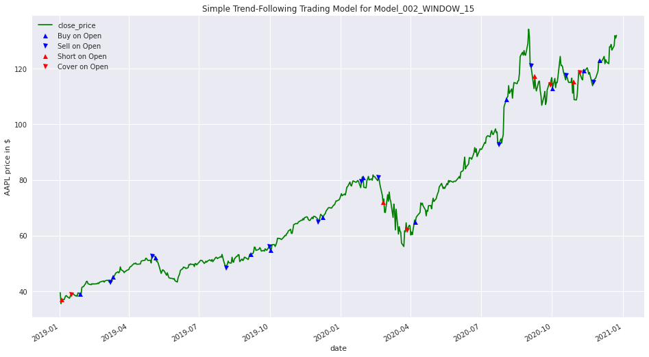

```python
draw_model_graph(trading_model_collection[top_model_name], top_model_name)
```

```python
print ('Total time for the script:',(datetime.now() - startTimeScript))
```

```
Total time for the script: 0:00:26.860291
```